# Gowinda Outputs: AUX - f_over_sum_known_trees: all, ce, w

Harrison Ostridge

2024-07-31

### Setup

```r
rm(list=ls())
knitr::opts_knit$set(root.dir = '~/OneDrive - University College London/Projects/Ostridge_PanAf/gowinda/baypass_aux/')
```

### Parameters

```r
subsps=c('all', 'ce', 'w')
env_data="f_over_sum_known_trees"
covs=c('f_over_sum_known_trees')
tails=c("fpr0.5pct.non-genic_1000bp.flanks", "fpr0.1pct.non-genic_1000bp.flanks", "fpr0.05pct.non-genic_1000bp.flanks")
tails_suffixs=c(".pos_beta", ".neg_beta")
```

This script plots the outputs from running Gowinda on the AUX candiadtes in `~/OneDrive - University College London/Projects/Ostridge_PanAf/gowinda/baypass_aux/scripts/run_gowinda.aux.general.Rmd`.

### Library

```r
library(data.table)
library(dplyr)
library(ggplot2)
library(wesanderson)
library(ggVennDiagram)
library(UpSetR)
library(tidyverse)
library(ggh4x)
library(ggvenn)
library(RColorBrewer)
library(plyr)
library(grid)
source("../baypass_core/scripts/plot_gowinda.R")
# Set fread to read in as a data frame by default
options(datatable.fread.datatable=FALSE)

gowinda_out_dir="output/gowinda_output/"
```

```r
datasets=c("go", "kegg", "reac", "gwas", "expr", "phen", "vips", "pathogen_ebel2017", "imm", "dehy")
```

#### Plot all genesets significant at least once across datasets and thresholds

The p_adjust option allows you to perform multiple testing correction across all gowinda runs if true. I do not do this because…

“Multiple testing corrections were done within each Gowinda run to account for the number of gene sets in each test (by calculating FDRs in Gowinda using the method described above) but not across Gowinda runs. This was done for two reasons. Firstly, each Gowinda analysis is not independent because the candidate tails are nested and the subspecies-specific subspecies-databases (Central-Eastern, Nigeria-Cameroon and Western) are all nested within All; therefore, multiple testing correction methods such as Benjamini and Hochberg correction (Benjamini and Hochberg 1995) would not be appropriate across this nested structure. Secondly, each gene set database is considered a separate analysis; the justification of this is that each is testing a different hypothesis. For example, there is a prior expectation for the importance of pathogens given previous results in chimpanzees (Pawar et al. 2022; Schmidt et al. 2019; Cagan et al. 2016), humans (Enard and Petrov 2018; Souilmi et al. 2021; Fumagalli et al. 2011) and other mammals (Enard et al. 2016). To test the hypothesis that chimpanzees show signatures of local adaptation to pathogens, I test for enrichment of 20 gene sets related to pathogens that are similar to pathogens known to infect wild chimpanzees; I argue it does not make sense to then correct for the fact that I also run a hypothesis-free test using 20,709 GO categories in a separate Gowinda analysis.”

# MAIN PLOT

```
## 0.1
```

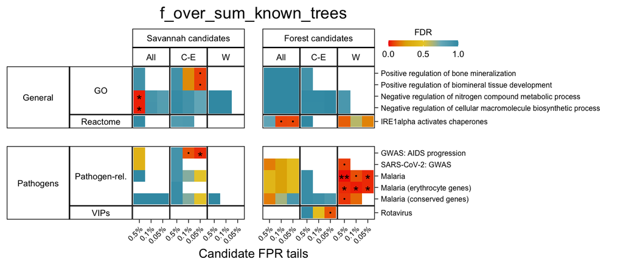

```
## 0.1
```

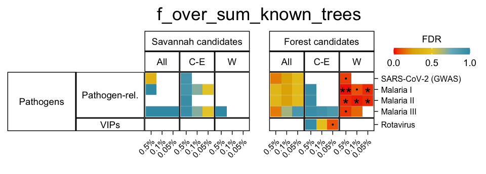

#### Table

```r
fdr_thresh=0.1

table_df=plot_df[c("Direction", "Category", "Dataset", "Subspecies", "gene_set_description", "Tail", "observed_hits", "fdr")]
table_df=table_df[order(table_df$Direction, table_df$Category, table_df$Dataset, table_df$Subspecies, table_df$gene_set_description, table_df$Tail, table_df$observed_hits, table_df$fdr), ]
table_df=table_df[complete.cases(table_df),]
table_df=table_df[table_df$fdr<fdr_thresh,]
colnames(table_df)[colnames(table_df)=="observed_hits"]="Number of candidate genes"
colnames(table_df)[colnames(table_df)=="gene_set_description"]="Gene set"
colnames(table_df)[colnames(table_df)=="fdr"]="FDR"
table_df$`Number of candidate genes`=gsub("\\*", "", table_df$`Number of candidate genes`)
table_df$Subspecies=gsub("\\\n", "", table_df$Subspecies)
table_df$Dataset=gsub("\\\n", " ", table_df$Dataset)
table_df$FDR=round(table_df$FDR, digits=3)

write.csv(table_df, paste0(gowinda_out_dir, "/",env_data,"/formatted_output/gea_gowinda_results.fdr_less_than_",fdr_thresh,".csv"),
          row.names = FALSE)
```

### Main Table

```
## 0.5
##  Forest
##   N General gene sets:  38
##   N Pathogen gene sets:  20
##  Savannah
##  N  General gene sets:  258
##  N  Pathogen gene sets:  12
```

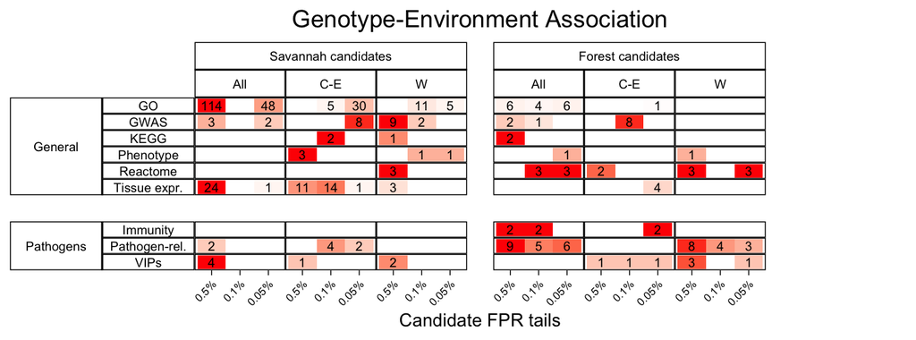

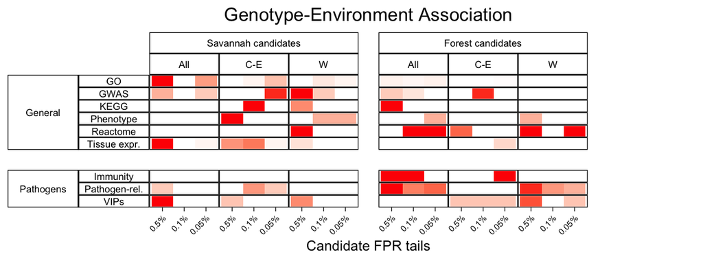

#### Dehydration plot

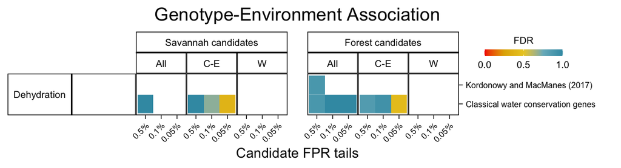